# KNeighborhood Scorer - Serial, MultiThreading, MapReduce Benchmark

Rashmi Dwaraka

10/06/2017

# KNeighborhood Scorer - Serial, MultiThreading, MapReduce Benchmark

## Neighborhood Score program

The Neighborhood Score program description is as below:

Letters are scored according to the rarity with which they appear in a given corpus (a large body of texts). Rare letters are worth more than common letters. Specifically, if a given letter makes up 10% or more of the letters in the entire corpus of text, its score is 0. If the letter makes up [8,10)% of the corpus (at least 8 but not more than 10 percent of the corpus), its score is 1. If it makes up [6,8)%, its score is 2. If it makes up [4,6)%, its score is 4. If it makes up [2,4)%, its score is 8. If the letter makes up [1,2)%, its score is 16. Otherwise, the score is 32. Whitespaces, numbers, and punctuation do not receive scores. Scoring is case-insensitive.

A word’s score is the sum of the scores of all its letters. A word’s k-neighborhood is the bag of k words appearing before it and k words appearing after it in the corpus.If a word appears in the corpus multiple times, it will have multiple k-neighborhoods. The score of a k-neighborhood is the sum of the scores of the words that are members of the k neighborhood.

## Benchmark - Experimental design

### Algorithm Design

#### KNeighborhood Scoring Algorithm

The previous algorithm was not scalable for huge data and I was unable to run the code for the big-corpus. The below algorithm makes the program scalable for huge corpus. The algorithm maintains a buffer of k words for each line and enables us to run any size data, as the in memory data structure is very small at all points of runtime.

*Sliding Window Algorithm for KNeighborhood*

- Step1 : Make 2 passes over each line of data. In first pass, find all the forrward neighbors excluding last k words In Second pass, find all the backword neighbors for all words keep last k words in a buffer, so that we can find its k neighbors while parsing next line
- Step2 : After each processing each line, we calculate the scores and merge to a global hashmap The hashmap stores {word,(score,count)}
- Step3 : The last k words of the file is merged to the hashmap and written to the output

*Modified Serial program for Scalability*

- Step1 : For all files in the input folder: For all lines in the file: Calculate the letter score based on its occurence
- Step2 : For all files in the input folder: For all lines in the file: Process the lines using above Sliding window algorithm Print the KNeighborhoodScore mean for each word alphabhetical order to CSV

*Modified Parallel program for Scalability*

- Step1 : For all files in the input folder: Created a callable instance to process the letter occurrence (No sharing of data) The result of each callable is passed to a future instance Once all futures are evaluated, merge the results to calculate global letter score
- Step2 : For all files in the input folder: Created a callable instance to process the lines using Sliding window algorithm with no sharing of data The result of each callable is passed to a future instance Once all futures are evaluated, merge the results to calculate global KNeighborhood word score Print the KNeighborhoodScore mean for each word alphabhetical order to CSV

*Modified Map-Reduce program (MEAN) for Accuracy and efficiency*

- Step1: The Letter count mapper is run on the entire corpus. For each mapper, create a global hashmap to keep track of count. Emit the count of the letters during the cleanup i,e, at the end of the Mapper task This reduces the number of for reducer and hence reduces sort and shufle time. Reducer, reduces each letter counts and aggregates to give us letter counts and total letters in the corpus.
- Step2: The letters are scored in the driver program, by reading the hdfs output file. The letter scores are written to file and placed in hdfs. (Alternate way to explore is to set the letter scores as configuration key-value. To be explored.)
- Step3: Use non-splitable files i,e, assign entire file to 1 mapper to maintain accuracy. Data Cleanser mapper, cleans the data by removing extra spaces and special characters and tokensizes the words. Each line with 10 words is emitted.
- Step4: The cleansed data is passed to kNeighborhood mapper and the KneighborScore mappers calculate the k neighbors and score them using sliding window approach. Each map emits the words with its (score,count) Reducer, reduces the word scores by combining all the possible kNeighbors for the word and calculates the mean - which is its Kneighborscore.

*Modified Map-Reduce program (MEDIAN) for Accuracy and efficiency*

### Hardware Specification

- Processor - 3.1 GHz Intel Core i7 with 4MB shared L3 cache.
- OS: MacOS Sierra - 10.12.4
- Memory: 16 GB 1867 MHz DDR3
- Number of cores - 2
- Number of threads - 4
- Hadoop: 2.8.1 (Pseudo Distribution mode)
- For Cluster - Amazon EMR - Amazon 2.7.3 (4 nodes and 2 nodes)

# Observations from the Benchmark Experiment

## Serial vs Parallel vs MapReduce

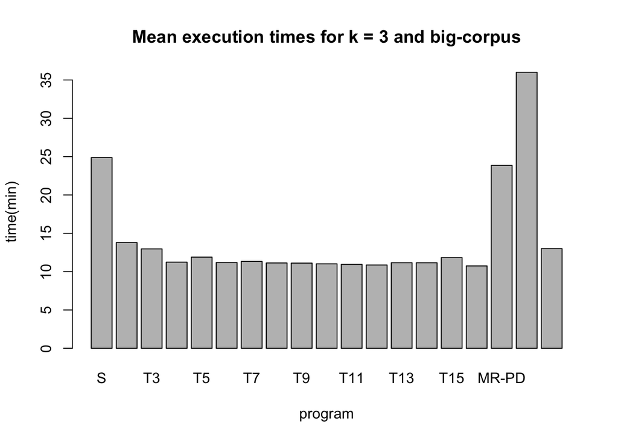

```r
x <-  vector();
x <-  c("S","T2","T3","T4","T5","T6","T7","T8","T9","T10","T11","T12","T13","T14","T15","T16","MR-PD","MR_4N","MR_2N")
t <- vector();
t <- c(24.8783,13.7881,12.968,11.2376,11.8932,11.1875,11.3340 ,11.1310 ,11.1138,11.0158 ,10.9424,10.8668 ,11.1562,11.1513 ,11.8337,10.7437, 23.8685 ,36,13)
exec <- data.frame(time = t, x = x)
barplot(exec$time,main="Mean execution times for k = 3 and big-corpus",xlab="program",ylab="time(min)",names.arg=x)
```

## Future Work

Create Multiple reducers to make reducing phase parallel. Also explore various optimization techniques of MapReduce